# Reconstruction of EOD Waveform Type Evolution in Paramormyrops kingsleyae using Parsimony, Stochastic Character Mapping and Joint Ancesteral Reconstruction

# Set up analysis

Specify the paths for the various input phylogenetic trees and phenotypic data

```r
paramormyrops_tree_file<-file.path(root,"output_data/04_Phylogeny_And_Admixture/pkings_iqtree_genes_astral_gcf_scf_tree.cf.tree.nex")
fish_data_file<-file.path(root,"input_data/01_Terra/data_model/fish_data_2024a.txt")
treefile<-file.path(root,"input_data/04_Phylogeny_And_Admixture/ssAll_iqtree_timtree.tree")
osteotree<-read.tree(treefile)
osteotree<-osteotree$`UTREE1=`

mormyrotree<-extract.clade(osteotree,220,root.edge=0,collapse.singles=TRUE)
```

```r
paramormyrops_tree<-read.nexus(paramormyrops_tree_file)
fish_data<-read.csv(fish_data_file,row.names=1,sep="\t")


cf_stats_file<-file.path(root,"output_data/04_Phylogeny_And_Admixture/pkings_iqtree_genes_astral_gcf_scf_tree.cf.stat")
cf_stats<-read.csv(cf_stats_file,sep="\t",comment.char = "#")

concord_factors<-cf_stats[c("ID","gCF","sCF")]

concord_factors <- concord_factors %>%
    mutate(new_label = paste0("gCF:",concord_factors$gCF,"\nsCF:",concord_factors$sCF))

cf_branch_file<-file.path(root,"output_data/04_Phylogeny_And_Admixture/pkings_iqtree_genes_astral_gcf_scf_tree.cf.branch")
cf_branch<-read.tree(cf_branch_file)

paramormyrops_tree$node.label<-cf_branch$node.label

label_lookup <- setNames(concord_factors$new_label, as.character(concord_factors$ID))

paramormyrops_tree$node.label<- sapply(paramormyrops_tree$node.label, function(x) {
    new_label <- label_lookup[as.character(x)]
    if(is.na(new_label)) return(x) else return(new_label)
})

pheno_discrete <- fish_data %>%
  mutate(Phenotype = factor(Phenotype)) %>%
  select(Phenotype)
```

Is there any missing samples between the phenotype file and the tree?

```r
phylo_samps<-paramormyrops_tree$tip.label
pheno_discrete_samps<-rownames(pheno_discrete)
setdiff(phylo_samps,pheno_discrete_samps)
```

```
character(0)
```

# Clean Up Tree (MAYBE UNCESSERSARY?)

```r
paramormyrops_tree<-drop.tip(paramormyrops_tree, c("PHOP_5511","BIK_6898"), trim.internal = TRUE)
paramormyrops_tree<-root(paramormyrops_tree,outgroup="PVAD_5505", resolve.root=TRUE)
```

# Let’s get some calibration points from Peterson et al. Tree

```r
crown<-getMRCA(mormyrotree,c("Paramormyrops_kingsleyae_SRR6507961","Paramormyrops_batesii_CU79740B"))
peterson_tree_paramormyrops<-extract.clade(mormyrotree,crown,root.edge=0,collapse.singles=TRUE)
```

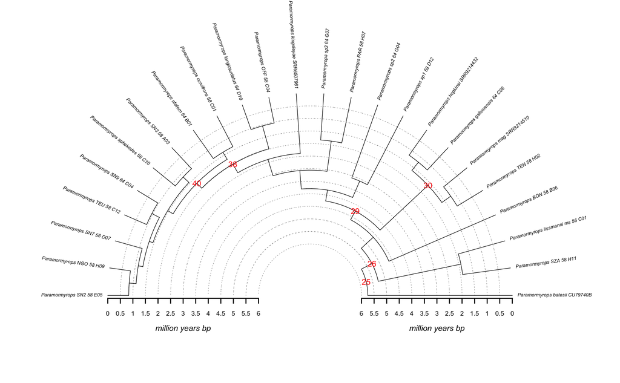

```r
crown<-getMRCA(peterson_tree_paramormyrops,c("Paramormyrops_SN2_58_E05","Paramormyrops_batesii_CU79740B"))
sza_mag<-getMRCA(peterson_tree_paramormyrops,c("Paramormyrops_mag_SRR9214510","Paramormyrops_SZA_58_H11"))
sn2_cur<-getMRCA(peterson_tree_paramormyrops,c("Paramormyrops_SN2_58_E05","Paramormyrops_curvifrons_58_C01"))
gab_mag<-getMRCA(peterson_tree_paramormyrops,c("Paramormyrops_gabonensis_64_C06","Paramormyrops_mag_SRR9214510"))
hop_cur<-getMRCA(peterson_tree_paramormyrops,c("Paramormyrops_curvifrons_58_C01","Paramormyrops_hopkinsi_SRR9214432"))
lon_sn2<-getMRCA(peterson_tree_paramormyrops,c("Paramormyrops_SN2_58_E05","Paramormyrops_longicaudatus_64_D10"))

times<-branching.times(peterson_tree_paramormyrops)

arctree(peterson_tree_paramormyrops,0.4)
peterson_nodes<-c(crown,sza_mag,sn2_cur,gab_mag,hop_cur,lon_sn2)
nodelabels(node=peterson_nodes, cex=1, frame="none", col="red")
```

```r
peterson_times<-times[as.character(peterson_nodes)]
```

```r
peterson_times
```

```
      25       26       40       30       29       38
5.750182 5.277729 1.704219 1.627047 4.237047 1.983209
```

```r
peterson_times_named<-peterson_times
```

```r
crown<-getMRCA(paramormyrops_tree,c("PVAD_5505","PSN2_616"))
sza_mag<-getMRCA(paramormyrops_tree,c("PSZA_454","PMAG_404"))
sn2_cur<-getMRCA(paramormyrops_tree,c("PSN2_616","PCUR_538"))
gab_mag<-getMRCA(paramormyrops_tree,c("PGAB_3980","PMAG_404"))
hop_cur<-getMRCA(paramormyrops_tree,c("PCUR_538","PHOP_505"))
lon_sn2<-getMRCA(paramormyrops_tree,c("PSN2_616","PLON_2190"))

paramormyrops_nodes<-c(crown,sza_mag,sn2_cur,gab_mag,hop_cur,lon_sn2)

paramormyrops_nodes
```

```
[1] 23 43 36 33 32 35
```

# Create a Time Calibrated Chronogram

Estimates of crown age come from timetree.org and Peterson et al. 2023 phylogeny

```r
mycalibration=makeChronosCalib(paramormyrops_tree,node=paramormyrops_nodes,age.min=peterson_times,age.max=peterson_times)
mycalibration
```

|  | node | age.min | age.max | soft.bounds |
| --- | --- | --- | --- | --- |
| 25 | 23 | 5.750182 | 5.750182 | FALSE |
| 26 | 43 | 5.277729 | 5.277729 | FALSE |
| 40 | 36 | 1.704219 | 1.704219 | FALSE |
| 30 | 33 | 1.627047 | 1.627047 | FALSE |
| 29 | 32 | 4.237047 | 4.237047 | FALSE |
| 38 | 35 | 1.983209 | 1.983209 | FALSE |

```r
ultrametric_rooted_tree <- chronos(paramormyrops_tree, lambda = .1, model = "discrete", calibration = mycalibration, control = chronos.control(dual.iter.max=100) )
```

```
Setting initial dates...
Fitting in progress... get a first set of estimates
         (Penalised) log-lik = -0.2280546
Optimising rates... frequencies... dates... -0.2280546
Optimising rates... frequencies... dates... -0.2279714
Optimising rates... frequencies... dates... -0.2279663

log-Lik = -0.2279661
PHIIC = 68.46
```

# Organize Phenotypes

Need to categorize assigned phenotypes as TP and BP, and for now we are converting wobbles for illustrative purposes.

```r
phenos<-setNames(as.character(pheno_discrete$Phenotype), row.names(pheno_discrete))
phenos <- gsub("TYPE_II", "TP", phenos)
phenos <- gsub("TYPE_I", "TP", phenos)
phenos<-as.factor(phenos)
## set colors for plotting

newphenos<-phenos[paramormyrops_tree$tip.label]
newphenos['APA_193']<-'TP'
newphenos['BAM_165']<-'BP'
newphenos<-droplevels(newphenos)
cols<-setNames(c("blue","red"),levels(newphenos))
```

# View Extant Character Distribution on the Phylogeny

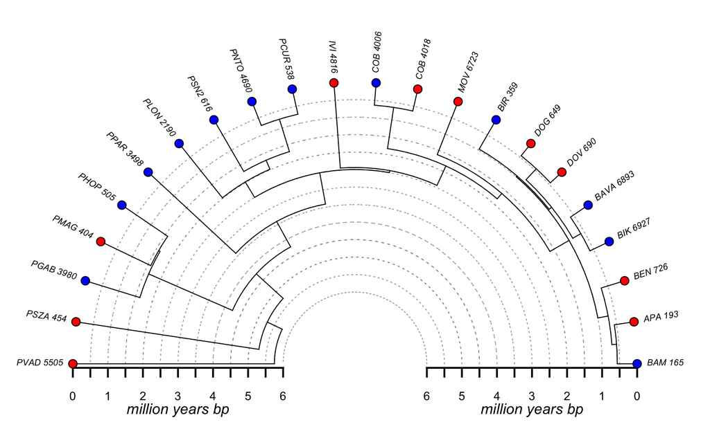

```r
arctree(ultrametric_rooted_tree,0.4)
tiplabels(pie=to.matrix(newphenos[ultrametric_rooted_tree$tip.label], levels(newphenos)), piecol=cols, cex=0.3)
```

# Using Parsimony to reconstruct character evolution.

See pg. 251 of Revell & Harmon (2022) “Comparative Phylogenetic Comparative Methods in R” - assumes rate of evolution is very slow.

```r
plot_name<-file.path(root,'output_data/04_Phylogeny_And_Admixture/paramormyrops_parsimony.svg')
svg(plot_name, width=12)  # Adjust width as needed
gp.int<-as.numeric(newphenos);
names(gp.int)<-names(newphenos)
gp.int <- gp.int[match(ultrametric_rooted_tree$tip.label,names(gp.int))]
anc.mp <- asr_max_parsimony(ultrametric_rooted_tree,gp.int)
arctree(ultrametric_rooted_tree,0.4)
tiplabels(pie=model.matrix(~as.factor(gp.int)-1),piecol=cols,cex=0.3)
nodelabels(node=1:ultrametric_rooted_tree$Nnode+Ntip(ultrametric_rooted_tree),
           pie=anc.mp$ancestral_likelihoods,piecol=cols,cex=0.3)
#edgelabels()
nodelabels(text=ultrametric_rooted_tree$node.label, adj=c(-.25,.25),frame="none",cex=0.5)
n<-dev.off()  # Close the SVG device
knitr::include_graphics(plot_name)
```

[output not shown]

# Joint Character Estimation

See pg. 238 Revell & Harmon (2022) “Comparative Phylogenetic Comparative Methods in R”: In joint ancestral state reconstruction, what we do is ask which set of character values at all the internal nodes maximizes the probability of obtaining the values for the character that we’ve observed at the tips of the tree, given our model.

Approach outlined here: http://blog.phytools.org/2024/04/a-few-useful-demos-on-ancestral-state.html

```r
## fit ER model
fitER<-fitMk(ultrametric_rooted_tree,newphenos,model="ER", pi=c(0,1),transform="delta")
## fit ARD model
fitARD<-fitMk(ultrametric_rooted_tree,newphenos,model="ARD",pi=c(0,1),transform="delta")
## fit SYM model
fitSYM<-fitMk(ultrametric_rooted_tree,newphenos,model="SYM",pi=c(0,1),transform="delta")

## fit directional model
directional<-matrix(c(0,0,1,0),2,2,byrow=TRUE)
fitDIR<-fitMk(ultrametric_rooted_tree,newphenos,model=directional,pi=c(0,1),transform="delta")
```

```r
## extract AIC values for each model
aic<-c(AIC(fitER),AIC(fitARD),AIC(fitSYM),AIC(fitDIR))
## print summary table

model_summary<-data.frame(
  model=c("ER","ARD","Symmetric","DIR"),
  logL=c(logLik(fitER),logLik(fitARD),logLik(fitSYM),logLik(fitDIR)),
  AIC=aic,delta.AIC=aic-min(aic),
  weight=unclass(aic.w(aic)))

model_summary
```

| model | logL | AIC | delta.AIC | weight |
| --- | --- | --- | --- | --- |
| ER | -15.22227 | 32.44454 | 0.000000 | 0.413647152 |
| ARD | -15.12143 | 34.24287 | 1.798330 | 0.168316881 |
| Symmetric | -15.22227 | 32.44454 | 0.000000 | 0.413647152 |
| DIR | -19.76822 | 41.53645 | 9.091908 | 0.004388815 |

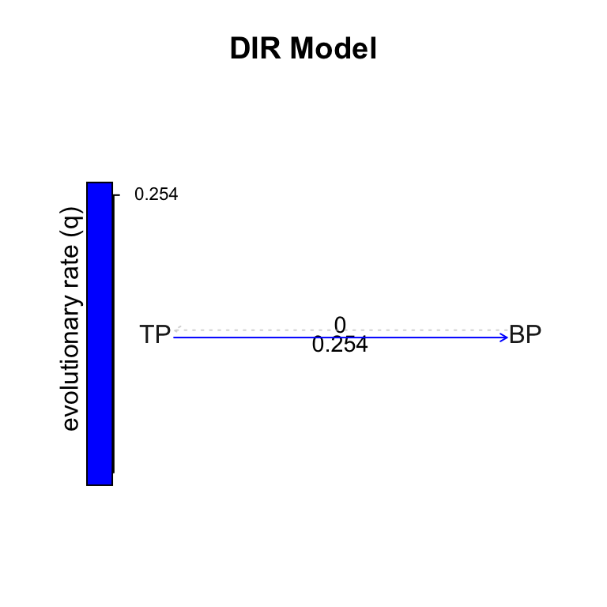

```r
  plot(fitDIR, width=TRUE, color=TRUE, cex.rates=0.9, main="DIR Model")
```

```r
mle.Q<-as.Qmatrix(fitDIR)
mle.Q
```

```
Estimated Q matrix:
          BP         TP
BP 0.0000000  0.0000000
TP 0.2539245 -0.2539245
```

```r
system.time(mtrees.sc<-make.simmap(ultrametric_rooted_tree,newphenos,Q=mle.Q, nsim=1000,pi=c(0,1)))
```

```
make.simmap is sampling character histories conditioned on
the transition matrix

Q =
          BP         TP
BP 0.0000000  0.0000000
TP 0.2539245 -0.2539245
(specified by the user);
and (mean) root node prior probabilities
pi =
BP TP
 0  1
```

```
Done.
```

```
   user  system elapsed
  4.765   0.010   4.772
```

```r
pd<-summary(mtrees.sc)
pd
```

```
1000 trees with a mapped discrete character with states:
 BP, TP

trees have 8.674 changes between states on average

changes are of the following types:
     BP,TP TP,BP
x->y     0 8.674

mean total time spent in each state is:
             BP         TP    total
raw  12.0951600 34.1583871 46.25355
prop  0.2614969  0.7385031  1.00000
```

```r
dd<-density(mtrees.sc)
dd
```

```
Distribution of changes from stochastic mapping:
    BP->TP      TP->BP
    Min.   :0   Min.   :8
    Median :0   Median :8
    Mean   :0   Mean   :8.67
    Max.   :0   Max.   :12

95% HPD interval(BP->TP): [0, 0]
95% HPD interval(TP->BP): [8, 10]
```

```r
plot_name<-file.path(root,'output_data/04_Phylogeny_And_Admixture/paramormyrops_character_map.svg')
svg(plot_name, width=12)  # Adjust width as needed
arctree(ultrametric_rooted_tree,0.4)
tiplabels(pie=to.matrix(newphenos[ultrametric_rooted_tree$tip.label], levels(newphenos)), piecol=cols, cex=0.3)
nodelabels(node=1:ultrametric_rooted_tree$Nnode+Ntip(ultrametric_rooted_tree),
           pie=pd$ace,piecol=cols,cex=0.4)
nodelabels(node=1:ultrametric_rooted_tree$Nnode+Ntip(ultrametric_rooted_tree),
           pie=pd$ace,piecol=cols,cex=0.4)
nodelabels(text=ultrametric_rooted_tree$node.label, adj=c(-.25,.25),frame="none",cex=0.5)
n<-dev.off()  # Close the SVG device
knitr::include_graphics(plot_name)
```

[output not shown]

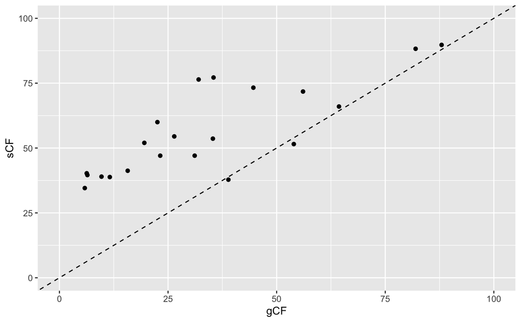

```r
ggplot(concord_factors,aes(x=gCF,y=sCF))+
  geom_point() +
  xlim(0, 100) +
    ylim(0, 100) +
    geom_abline(slope = 1, intercept = 0, linetype = "dashed")
```